# Tugas TPG 9

Fahmim

2025-11-12

# Library yang diperlukan

```r
library(cluster)
library(factoextra)
library(clusterCrit)
library(dplyr)
library(ggplot2)
library(tidyr)
library(scales)
library(readxl)
library(RColorBrewer)
```

# Baca Data

```r
data_raw <- read_excel("E:/(1) Projects/Semester 5/Teknik Peubah Ganda/AirQualityUCI.xlsx")
head(data_raw)
```

```
## # A tibble: 6 × 4
##   `CO(GT)` `NOx(GT)`     T    RH
##      <dbl>     <dbl> <dbl> <dbl>
## 1      1.2        62  11.3  56.8
## 2      1          62  10.7  60
## 3      0.9        45  10.7  59.7
## 4      0.7        16  11.0  56.2
## 5      0.7        34  10.5  58.1
## 6      1.1        98  10.2  59.6
```

# Pre-Processing

```r
data_scaled <- scale(data_raw)
head(data_scaled)
```

```
##          CO(GT)    NOx(GT)          T        RH
## [1,] -0.8540407 -1.0312693 -0.7463001 0.5229217
## [2,] -1.0018096 -1.0312693 -0.8910016 0.7471800
## [3,] -1.0756940 -1.2375754 -0.8965670 0.7245803
## [4,] -1.2234629 -1.5895092 -0.8186508 0.4811992
## [5,] -1.2234629 -1.3710675 -0.9410905 0.6167973
## [6,] -0.9279251 -0.5943859 -0.9967450 0.7193650
```

# Metode clustering non-hierarki: K-Means CLustering

## Penentuan jumlah cluster optimal

Menentukan jumlah cluster terbaik (k) dapat menggunakan dua metode populer:

Elbow Method: melihat titik siku (elbow point) pada grafik within-cluster sum of squares (WSS).

Silhouette Method: menilai kualitas pemisahan cluster; semakin tinggi nilai silhouette, semakin baik hasil clustering.

### ELbow method

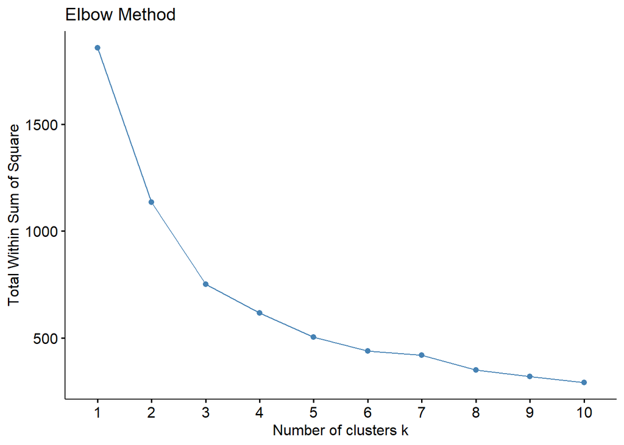

```r
fviz_nbclust(data_scaled, kmeans, method = "wss") +
labs(title = "Elbow Method")
```

### Silhouette method

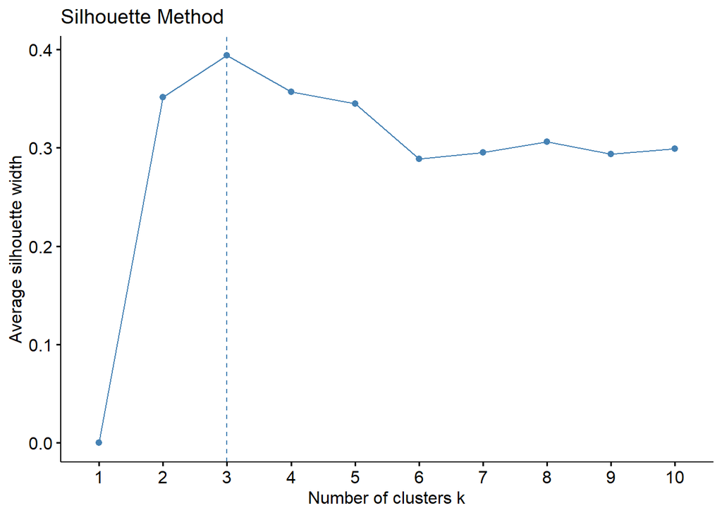

```r
fviz_nbclust(data_scaled, kmeans, method = "silhouette") +
labs(title = "Silhouette Method")
```

## Penerapan Algoritma K-Means

Setelah melihat dari pola menggunakan Elbow Method dan Silhoutte, diperoleh pengelompokan yang terbaik itu 3. Selabjutnya dilakukan proses clustering menggunakan fungsi kmeans().

```r
set.seed(1040)
kmeans_air_result <- kmeans(data_scaled, centers = 3, nstart = 465)
kmeans_air_result
```

```
## K-means clustering with 3 clusters of sizes 117, 125, 223
##
## Cluster means:
##        CO(GT)     NOx(GT)          T         RH
## 1  1.29113433  1.30427293 -0.0093941  0.1269247
## 2 -0.02889915 -0.08041682  1.1390199 -1.2129605
## 3 -0.66121221 -0.63922794 -0.6335353  0.6133178
##
## Clustering vector:
##   [1] 3 3 3 3 3 3 3 3 3 3 3 3 3 3 3 1 1 1 1 1 3 3 3 3 3 3 3 3 1 1 1 2 2 2 2 2 2
##  [38] 1 1 1 1 1 1 3 3 3 3 3 3 1 1 1 1 1 2 2 2 2 2 1 1 1 1 1 1 1 1 3 3 3 3 3 3 3
##  [75] 2 2 2 2 2 2 2 2 1 1 1 3 3 3 3 3 3 3 3 1 1 1 1 2 2 2 2 2 2 1 1 1 1 1 3 3 3
## [112] 3 3 3 3 1 1 1 1 2 2 2 2 2 2 2 2 2 1 2 3 3 3 3 3 3 3 1 1 1 2 2 2 2 2 2 2 2
## [149] 1 1 1 2 1 3 3 3 3 3 3 1 1 1 2 2 2 2 2 2 2 2 1 1 1 3 3 3 3 3 3 3 3 1 1 1 1
## [186] 1 1 1 1 1 1 1 1 1 1 3 3 3 3 3 3 3 3 3 3 3 1 1 2 2 2 2 2 2 1 1 1 3 3 1 3 3
## [223] 3 3 3 3 3 3 2 2 2 2 2 2 2 1 1 1 1 3 3 3 3 3 3 3 3 1 1 2 2 2 2 2 2 2 2 1 1
## [260] 1 1 3 3 3 3 3 3 3 3 1 1 1 1 1 1 2 3 3 1 3 3 1 3 3 3 3 3 3 3 3 3 1 1 1 3 2
## [297] 2 2 3 3 3 1 1 3 3 3 3 3 3 3 3 3 3 3 1 3 3 3 3 3 2 2 2 2 1 1 3 3 3 3 3 3 3
## [334] 3 3 3 1 1 1 2 2 2 2 3 3 3 3 3 3 3 3 3 3 3 3 3 3 3 3 3 2 2 2 2 2 2 2 2 2 1
## [371] 1 3 3 3 3 3 3 3 3 3 3 3 3 2 2 2 2 2 2 2 2 2 3 3 3 3 3 3 3 3 3 3 3 3 1 3 2
## [408] 2 2 2 2 2 2 2 2 2 3 3 2 3 2 3 3 3 3 1 1 1 1 2 2 2 2 2 2 2 2 2 2 3 3 3 3 3
## [445] 3 3 3 3 1 1 3 3 3 1 3 3 1 3 3 3 3 3 3 3 3
##
## Within cluster sum of squares by cluster:
## [1] 282.3682 181.7110 286.9539
##  (between_SS / total_SS =  59.5 %)
##
## Available components:
##
## [1] "cluster"      "centers"      "totss"        "withinss"     "tot.withinss"
## [6] "betweenss"    "size"         "iter"         "ifault"
```

## Hasil Clustering

```r
head(data.frame(Observasi = 1:length(kmeans_air_result$cluster),
           Cluster = kmeans_air_result$cluster),10)
```

```
##    Observasi Cluster
## 1          1       3
## 2          2       3
## 3          3       3
## 4          4       3
## 5          5       3
## 6          6       3
## 7          7       3
## 8          8       3
## 9          9       3
## 10        10       3
```

### Jumlah amatan setiap cluster

```r
table(kmeans_air_result$cluster)
```

```
##
##   1   2   3
## 117 125 223
```

### Label Cluster untuk setiap observasi

```r
kmeans_air_result$cluster
```

```
##   [1] 3 3 3 3 3 3 3 3 3 3 3 3 3 3 3 1 1 1 1 1 3 3 3 3 3 3 3 3 1 1 1 2 2 2 2 2 2
##  [38] 1 1 1 1 1 1 3 3 3 3 3 3 1 1 1 1 1 2 2 2 2 2 1 1 1 1 1 1 1 1 3 3 3 3 3 3 3
##  [75] 2 2 2 2 2 2 2 2 1 1 1 3 3 3 3 3 3 3 3 1 1 1 1 2 2 2 2 2 2 1 1 1 1 1 3 3 3
## [112] 3 3 3 3 1 1 1 1 2 2 2 2 2 2 2 2 2 1 2 3 3 3 3 3 3 3 1 1 1 2 2 2 2 2 2 2 2
## [149] 1 1 1 2 1 3 3 3 3 3 3 1 1 1 2 2 2 2 2 2 2 2 1 1 1 3 3 3 3 3 3 3 3 1 1 1 1
## [186] 1 1 1 1 1 1 1 1 1 1 3 3 3 3 3 3 3 3 3 3 3 1 1 2 2 2 2 2 2 1 1 1 3 3 1 3 3
## [223] 3 3 3 3 3 3 2 2 2 2 2 2 2 1 1 1 1 3 3 3 3 3 3 3 3 1 1 2 2 2 2 2 2 2 2 1 1
## [260] 1 1 3 3 3 3 3 3 3 3 1 1 1 1 1 1 2 3 3 1 3 3 1 3 3 3 3 3 3 3 3 3 1 1 1 3 2
## [297] 2 2 3 3 3 1 1 3 3 3 3 3 3 3 3 3 3 3 1 3 3 3 3 3 2 2 2 2 1 1 3 3 3 3 3 3 3
## [334] 3 3 3 1 1 1 2 2 2 2 3 3 3 3 3 3 3 3 3 3 3 3 3 3 3 3 3 2 2 2 2 2 2 2 2 2 1
## [371] 1 3 3 3 3 3 3 3 3 3 3 3 3 2 2 2 2 2 2 2 2 2 3 3 3 3 3 3 3 3 3 3 3 3 1 3 2
## [408] 2 2 2 2 2 2 2 2 2 3 3 2 3 2 3 3 3 3 1 1 1 1 2 2 2 2 2 2 2 2 2 2 3 3 3 3 3
## [445] 3 3 3 3 1 1 3 3 3 1 3 3 1 3 3 3 3 3 3 3 3
```

### Total keragaman dalam data

```r
kmeans_air_result$totss
```

```
## [1] 1856
```

### Keragaman dalam masing-masing cluster

```r
kmeans_air_result$withinss
```

```
## [1] 282.3682 181.7110 286.9539
```

### Total keragaman dalam cluster

```r
kmeans_air_result$tot.withinss
```

```
## [1] 751.0332
```

### Keragaman antar cluster

```r
kmeans_air_result$betweenss
```

```
## [1] 1104.967
```

### Jumlah iterasi hingga konvergen

```r
kmeans_air_result$iter
```

```
## [1] 3
```

## Evaluasi Clustering

```r
cluster_km_air <- kmeans_air_result$cluster
dist_matrix_air <- dist(data_scaled, method = "euclidean")

sil <- mean(silhouette(cluster_km_air, dist_matrix_air)[, 3])
ch <- intCriteria(traj = as.matrix(data_scaled),
part = cluster_km_air,
crit = "Calinski_Harabasz")$calinski_harabasz
dunn <- intCriteria(traj = as.matrix(data_scaled),
part = cluster_km_air,
crit = "Dunn")$dunn

data.frame(Silhouette = sil,
Calinski_Harabasz = ch,
Dunn = dunn)
```

```
##   Silhouette Calinski_Harabasz       Dunn
## 1  0.3937749          339.8616 0.03212287
```

## Karakteristik CLustering

```r
data_air_clustered <- data.frame(data_raw, cluster = factor(cluster_km_air))

cluster_air_summary <- data_air_clustered %>%
group_by(cluster) %>%
summarise(across(where(is.numeric), mean, .names = "{.col}"))

cluster_air_summary
```

```
## # A tibble: 3 × 5
##   cluster CO.GT. NOx.GT.     T    RH
##   <fct>    <dbl>   <dbl> <dbl> <dbl>
## 1 1         4.10   254.   14.6  51.1
## 2 2         2.32   140.   19.8  31.8
## 3 3         1.46    94.3  11.8  58.1
```

## Visualisasi Clustering

### Plot CLustering

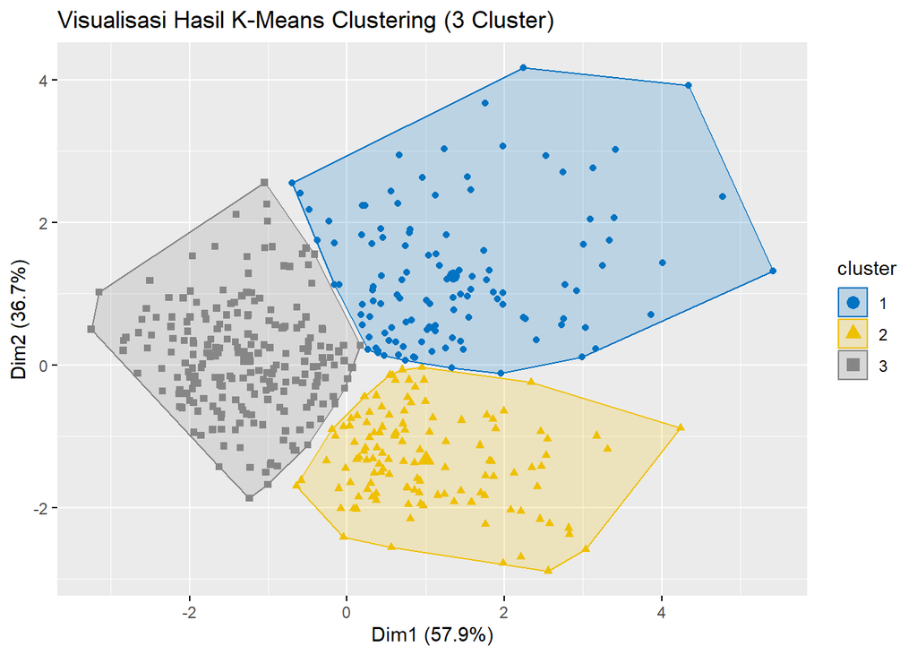

```r
fviz_cluster(kmeans_air_result, data= data_scaled,
palette = "jco", geom = "point",
main = "Visualisasi Hasil K-Means Clustering (3 Cluster)")
```

```r
heat_data_air <- cluster_air_summary %>%
pivot_longer(-cluster, names_to = "Variabel", values_to = "Rata2")
heat_data_air
```

```
## # A tibble: 12 × 3
##    cluster Variabel  Rata2
##    <fct>   <chr>     <dbl>
##  1 1       CO.GT.     4.10
##  2 1       NOx.GT.  254.
##  3 1       T         14.6
##  4 1       RH        51.1
##  5 2       CO.GT.     2.32
##  6 2       NOx.GT.  140.
##  7 2       T         19.8
##  8 2       RH        31.8
##  9 3       CO.GT.     1.46
## 10 3       NOx.GT.   94.3
## 11 3       T         11.8
## 12 3       RH        58.1
```

Berdasarkan hasil clustering dan visualisasi tersebut, dapat disimpulkan bahwa *clustering 1 (Biru) merupakan Zona Udara Sangat Terpolusi (Polusi Tinggi)*. Cluster ini memiliki rata-rata $\text{CO(GT)}$ (4.10) dan $\text{NOx(GT)}$ (254) yang jauh lebih tinggi dibandingkan cluster lainnya. Cluster 1 mewakili kondisi atau periode waktu di mana kualitas udara berada pada tingkat terburuk atau paling terpolusi.

Sedangkan, *clustering 2 (Kuning) Zona Udara Terpolusi Sedang (Polusi Menengah)*. Nilai rata-rata $\text{CO(GT)}$ (2.32) dan $\text{NOx(GT)}$ (140) berada di antara Cluster 1 dan Cluster 3. Cluster 2 mewakili kondisi kualitas udara yang moderat atau menengah. Ini bisa menjadi kondisi transisi antara polusi tinggi dan rendah.

Terakhir, *clustering 3 Zona Udara Relatif Bersih (Polusi Rendah)*. Cluster ini memiliki rata-rata $\text{CO(GT)}$ (1.46) dan $\text{NOx(GT)}$ (94.3) yang paling rendah di antara ketiga cluster. Cluster 3 mewakili kondisi atau periode waktu di mana kualitas udara berada pada tingkat terbaik atau relatif paling bersih.

Plot ini mendukung hasil tabel rata-rata. Tiga kelompok amatan yang berbeda telah berhasil diidentifikasi, dan berdasarkan tabel, perbedaan utama antar kelompok tersebut adalah tingkat polusi udara.

### Heatmap Clustering

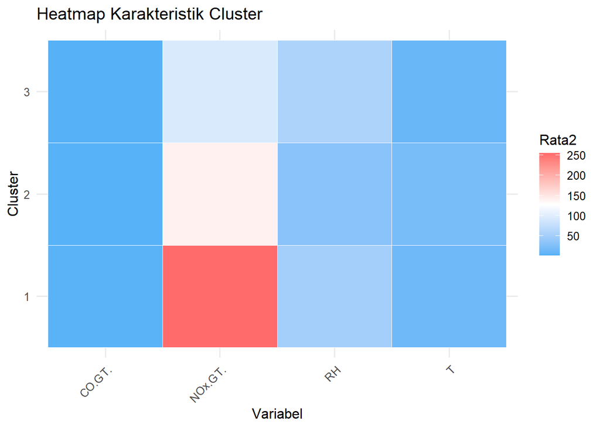

```r
ggplot(heat_data_air, aes(x = Variabel, y = cluster, fill = Rata2)) +
geom_tile(color = "white") +
scale_fill_gradientn(colors = c("#56B1F7", "white", "#FF6B6B")) +
labs(title = "Heatmap Karakteristik Cluster",
x = "Variabel", y = "Cluster") +
theme_minimal(base_size = 12) +
theme(axis.text.x = element_text(angle = 45, hjust = 1))
```

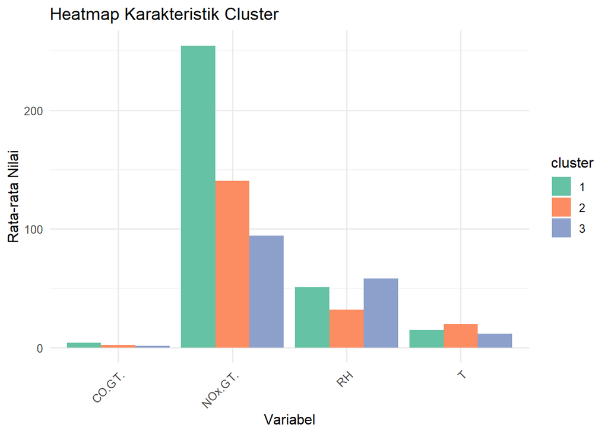

```r
ggplot(heat_data_air, aes(x = Variabel, y = Rata2, fill = cluster)) +
geom_bar(stat = "identity", position = "dodge") +
scale_fill_brewer(palette = "Set2") +
labs(title = "Heatmap Karakteristik Cluster",
x = "Variabel", y = "Rata-rata Nilai") +
theme_minimal(base_size = 12) +
theme(axis.text.x = element_text(angle = 45, hjust = 1))
```

Pada kedua heatmap, variabel $\text{CO.GT.}$ dan $\text{NOx.GT.}$ menunjukkan pola yang hampir identik:

Cluster 1 (Merah/Hijau Terang): Memiliki rata-rata tertinggi untuk $\text{CO.GT.}$ dan $\text{NOx.GT.}$.Cluster 1 dicirikan oleh tingkat polusi udara yang sangat tinggi (baik Karbon Monoksida maupun Nitrogen Oksida).

Cluster 3 (Biru Tergelap): Memiliki rata-rata terendah untuk $\text{CO.GT.}$ dan $\text{NOx.GT.}$. Cluster 3 dicirikan oleh kualitas udara yang terbaik atau paling rendah polusinya.

Cluster 2 (Putih/Oranye): Memiliki rata-rata menengah untuk kedua polutan tersebut.Cluster 2 mewakili kondisi polusi udara sedang/moderat.

Pola ini mengkonfirmasi interpretasi sebelumnya: K-Means berhasil membagi data menjadi tiga tingkatan kualitas udara: Buruk (Cluster 1), Sedang (Cluster 2), dan Baik (Cluster 3).

Variabel $\text{RH}$ dan $\text{T}$ menunjukkan pola yang berbeda dari polutan, yang membantu membedakan Cluster 2 dan 3 lebih lanjut.

Cluster 3: Memiliki rata-rata $\text{RH}$ tertinggi (sekitar $\text{55\% - 60\%}$).

Cluster 1: Memiliki rata-rata $\text{RH}$ menengah (sekitar $\text{50\%}$).

Cluster 2: Memiliki rata-rata $\text{RH}$ terendah (sekitar $\text{30\% - 40\%}$).

Cluster 1: Memiliki rata-rata $\text{T}$ menengah (sekitar $\text{15}^\circ\text{C}$).

Cluster 3: Memiliki rata-rata $\text{T}$ terendah (sekitar $\text{10}^\circ\text{C}$).

# Kesimpulan

*Cluster 1* mendefinisikan amatan ketika polusi mencapai puncaknya, terlepas dari faktor suhu dan kelembaban (yang berada di nilai tengah). *Cluster 2* mendefinisikan amatan ketika lingkungan berada dalam kondisi panas dan kering (T tinggi, RH rendah), yang bersamaan dengan tingkat polusi sedang. *Cluster 3* mendefinisikan amatan ketika lingkungan dingin dan lembab (T rendah, RH tinggi), yang berasosiasi dengan tingkat polusi terendah.